# Estudio estadístico sobre teleorientación psicológica dirigido a usuarios de Óyeme mayores de 18 años que requieran atención para la salud mental debido a la pandemia atravesada

### Regresión 3

La variable Situaciones (Situaciones de estrés) representará la variable dependiente “y” y la variable Edad (Edad de los encuestados) será la variable independiente “x”.

Se calculará el promedio de la data debido a que esta presenta cierto grado de variabilidad.

```r
# y = Situaciones - Dependiente
# x = Edad - Independiente
y=vector()
S=DFN$Situaciones[DFN$Edad>17]
y=append(y,mean(S,na.rm=TRUE))
x=vector()
x=c(17)
for (i in 17:44){
  if(i%%4==0){
    i=i+1
    S=DFN$Situaciones[DFN$Edad>=(i) & DFN$Edad<i+5]
    y=append(y,mean(S,na.rm=TRUE))
    in_g=((i +i+4)/2)
    x=append(x,in_g)
  }
}
data3 = data.frame(cbind(y,x))
data3 <- data3[data3$y != "NaN",]
data3
```

```
##          y  x
## 1 3.456954 17
## 2 3.438202 23
## 3 3.545455 27
## 4 2.666667 31
## 5 4.000000 35
## 7 3.000000 43
```

La variable data contiene a los puntos en “x” (edad de los encuestados) y en “y” (situaciones de estrés de los encuestados). Estos vectores serán usados en todo el proceso de regresión simple.

Se procede a graficar la regresión y los puntos “x” e “y”.

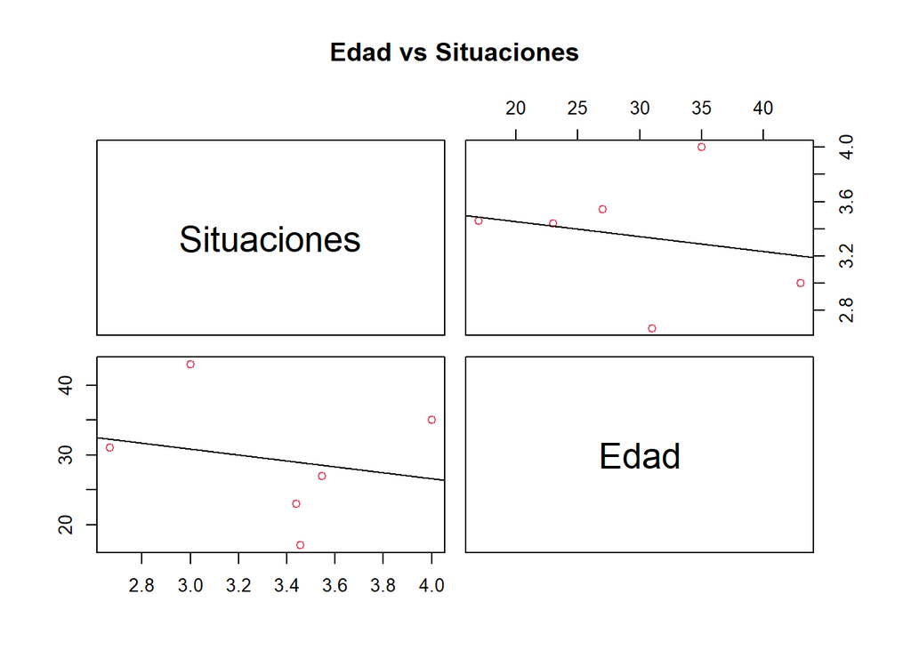

```r
# Graficar la funcion lineal
reg <- function(x, y, ...) {
  points(x,y, ...)
  abline(lm(y~x), lwd=1)
}

  pairs(data3, labels = c("Situaciones", "Edad"),main="Edad vs Situaciones", col=2, upper.panel = reg, lower.panel = reg)
```

#### Correlación entre las variables

```r
cor(data3)
```

```
##            y          x
## y  1.0000000 -0.2159374
## x -0.2159374  1.0000000
```